# NFL 2020 Week 19

# Cadet Individual Results

MA206 Individual Results

Week 19

Name

Weekly # Correct

Percent

Weeks Picked

Season Percent

Adj Season Percent

Season Trend

Week 1

Week 2

Week 3

Week 4

Week 5

Week 6

Week 7

Week 8

Week 9

Week 10

Week 11

Week 12

Week 13

Week 14

Week 15

Week 16

Week 17

Week 18

Week 19

Caroline Swenson

8

12

11

13

7

8

10

NA

8

9

8

NA

12

11

12

8

13

4

3

0.75

17

0.6767

0.6055

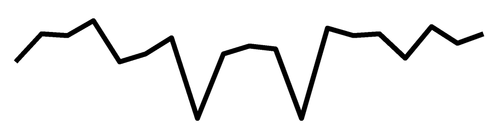

Sydney Shannon

10

9

8

9

8

7

9

5

8

10

8

10

11

10

11

12

12

4

3

0.75

19

0.6260

0.6260

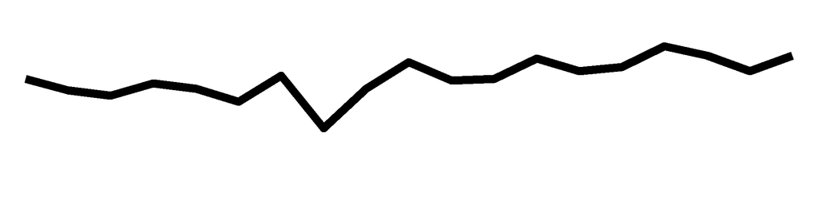

Gabriela Peralta

11

8

9

NA

8

8

10

6

NA

8

6

10

12

NA

12

NA

NA

4

3

0.75

14

0.6150

0.4532

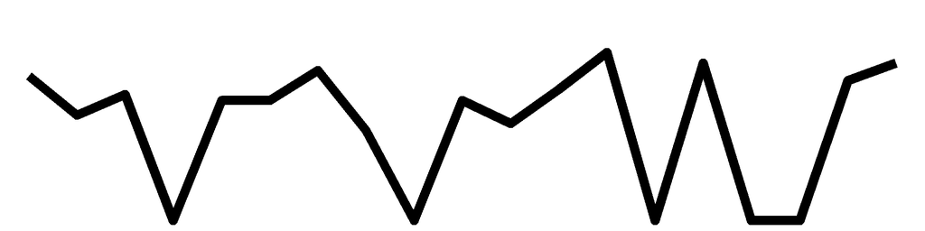

John White

10

11

10

8

12

9

11

6

9

9

8

10

8

11

10

10

12

6

2

0.50

19

0.6565

0.6565

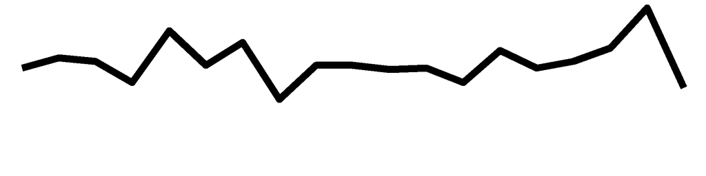

Thomas Bizub

10

14

8

11

8

9

10

8

10

12

9

11

9

10

NA

NA

NA

NA

NA

0.00

14

0.6780

0.4996

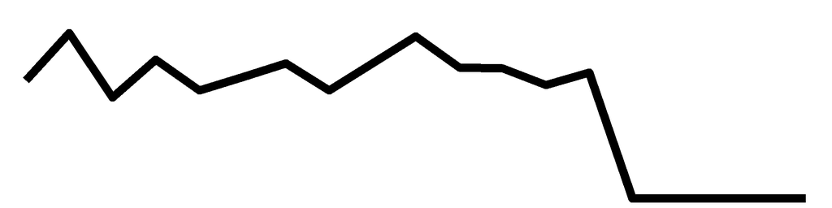

Amadou Bah

9

NA

NA

NA

NA

NA

NA

NA

NA

NA

NA

NA

NA

NA

NA

12

NA

NA

NA

0.00

2

0.6774

0.0713

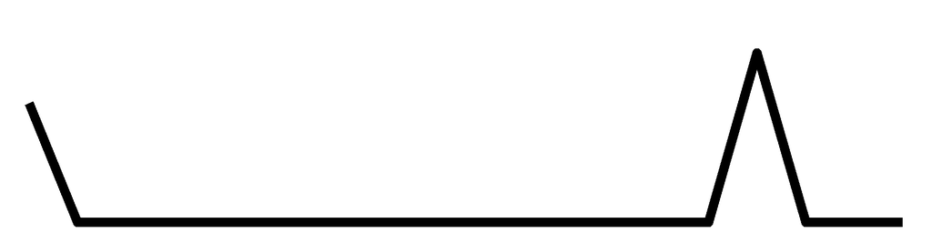

Kieran Place

12

11

8

NA

10

10

9

NA

NA

NA

NA

NA

NA

NA

NA

NA

NA

NA

NA

0.00

6

0.6742

0.2129

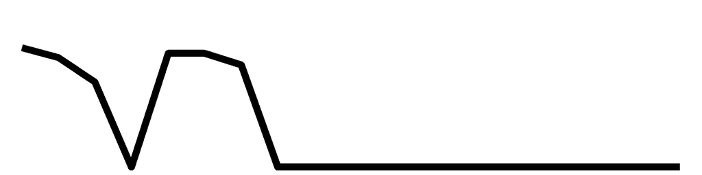

Luca Testa

NA

NA

10

NA

NA

NA

NA

NA

NA

NA

NA

NA

NA

NA

NA

NA

NA

NA

NA

0.00

1

0.6667

0.0351

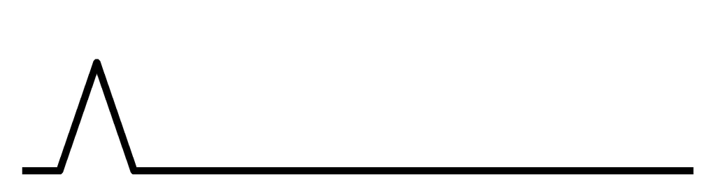

Laurence Dowd

10

10

10

9

10

NA

12

NA

10

8

7

NA

10

NA

NA

NA

NA

NA

NA

0.00

10

0.6575

0.3461

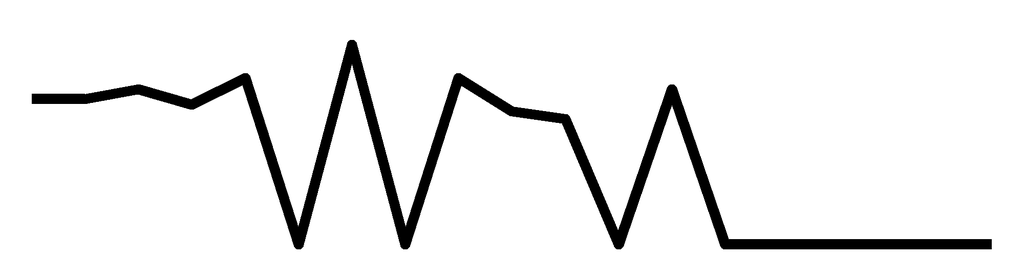

Joshua Loyd

11

9

8

NA

6

9

NA

6

10

8

NA

10

9

11

12

12

13

3

NA

0.00

15

0.6343

0.5008

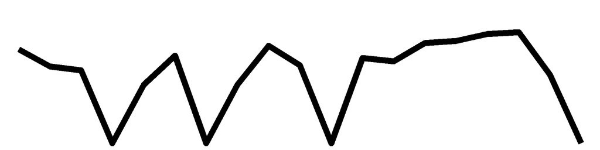

Jonathan Kemp

10

10

NA

NA

11

10

11

7

8

6

8

12

8

9

NA

NA

NA

NA

NA

0.00

12

0.6286

0.3970

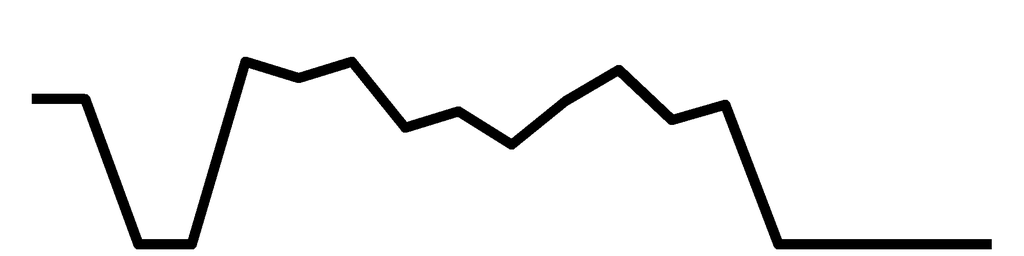

Paige Lennon

NA

NA

NA

11

10

8

11

8

6

8

6

9

11

10

11

NA

NA

NA

NA

0.00

12

0.6264

0.3956

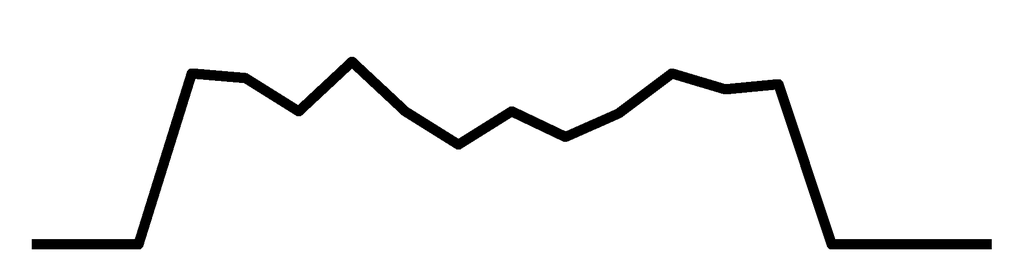

Zakai Bufkin

8

11

7

9

8

10

9

7

9

9

NA

10

NA

NA

NA

12

NA

NA

NA

0.00

12

0.6158

0.3889

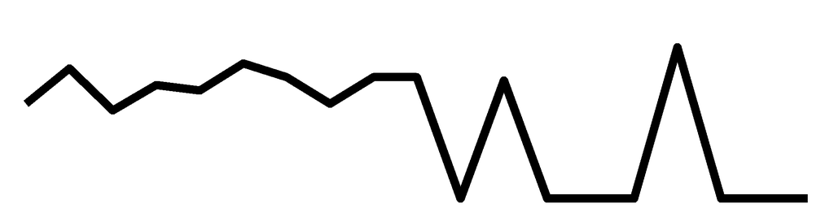

Christopher Erb

9

9

7

11

9

11

8

11

10

9

5

10

9

8

NA

NA

NA

NA

NA

0.00

14

0.6146

0.4529

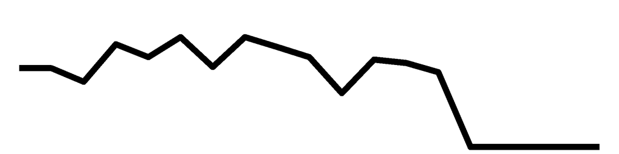

Victor Olawale-Apanpa

8

NA

10

NA

10

NA

10

7

7

9

6

11

10

NA

NA

NA

NA

NA

NA

0.00

10

0.6069

0.3194

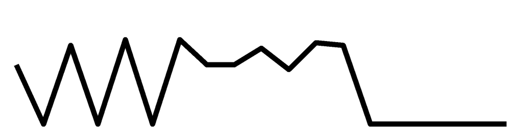

Sidney Cash

10

10

NA

10

NA

8

8

7

11

8

5

10

10

8

NA

NA

NA

NA

NA

0.00

12

0.5966

0.3768

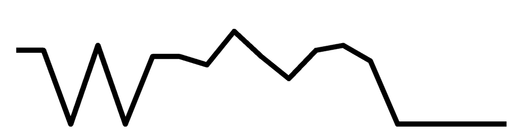

Cameron Patterson

11

9

8

NA

NA

NA

NA

NA

NA

NA

NA

NA

NA

NA

NA

NA

NA

NA

NA

0.00

3

0.5957

0.0941

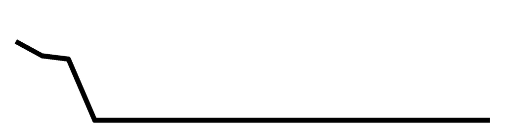

Joshua Gilliard

9

8

9

10

10

7

10

7

5

8

NA

10

10

NA

NA

NA

NA

NA

NA

0.00

12

0.5819

0.3675

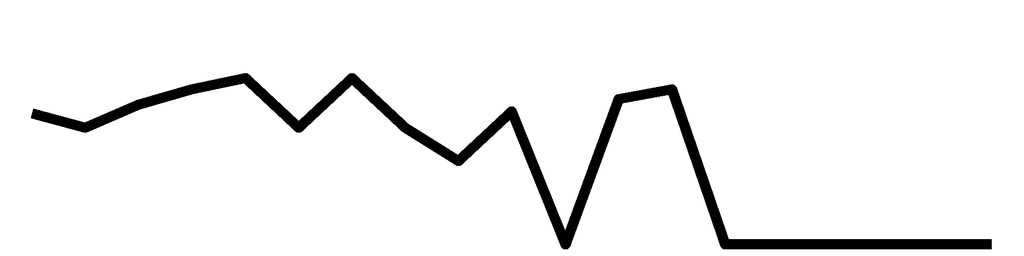

Margaret Williams

9

NA

NA

NA

NA

NA

NA

NA

NA

NA

NA

NA

NA

NA

NA

NA

NA

NA

NA

0.00

1

0.5625

0.0296

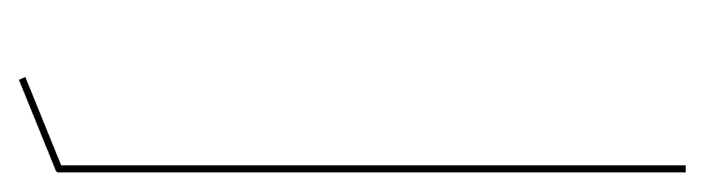

Logan Kauina

9

NA

NA

NA

NA

NA

NA

NA

NA

NA

NA

NA

NA

NA

NA

NA

NA

NA

NA

0.00

1

0.5625

0.0296

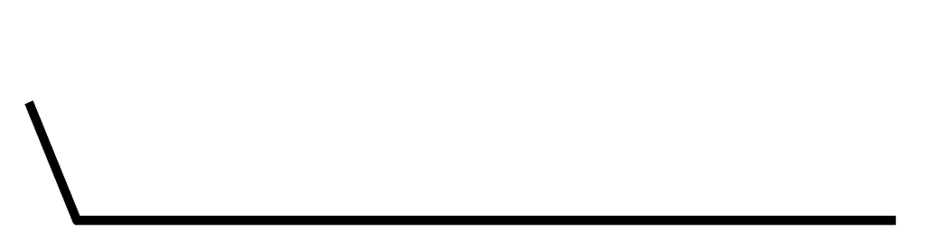

Caleb John

NA

9

NA

NA

NA

NA

NA

NA

NA

NA

NA

NA

NA

NA

NA

NA

NA

NA

NA

0.00

1

0.5625

0.0296

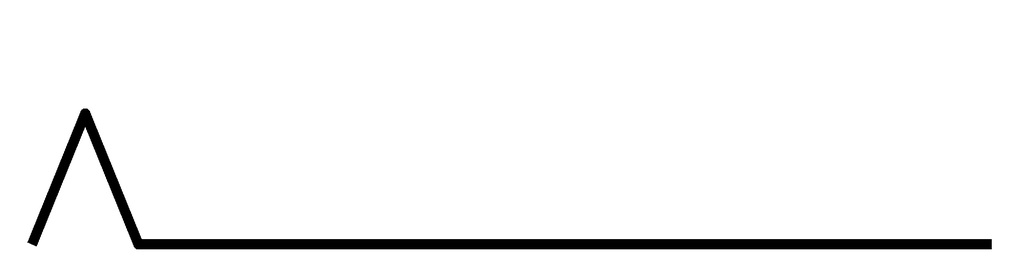

Jay Hajost

11

7

10

NA

6

NA

NA

7

9

NA

NA

NA

NA

NA

NA

NA

NA

NA

NA

0.00

6

0.5618

0.1774

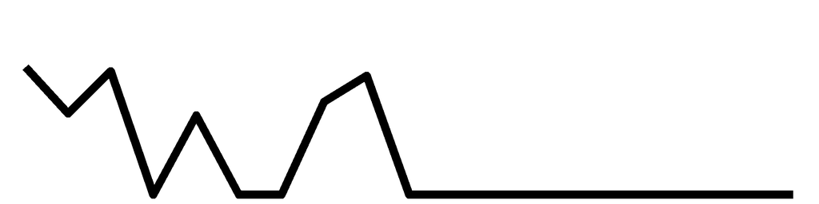

Ryan Jackovic

11

10

NA

7

7

8

8

7

NA

4

5

NA

12

10

NA

NA

NA

NA

NA

0.00

11

0.5562

0.3220

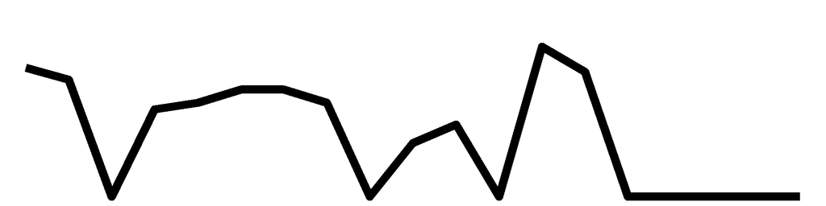

August Rannow

9

NA

NA

NA

7

NA

NA

NA

NA

NA

NA

NA

NA

NA

NA

NA

NA

NA

NA

0.00

2

0.5333

0.0561

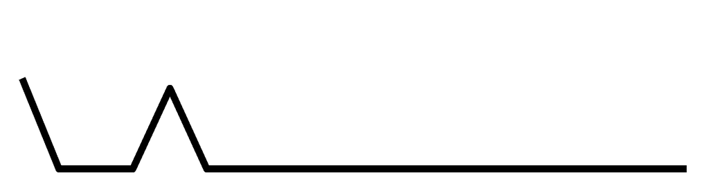

Peter Digenan

9

6

8

10

7

NA

NA

NA

NA

NA

NA

NA

NA

NA

NA

NA

NA

NA

NA

0.00

5

0.5263

0.1385

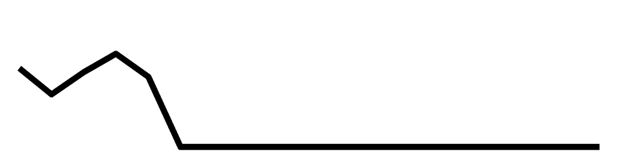

Caleb Doyle

9

NA

NA

NA

NA

NA

NA

6

NA

NA

NA

NA

NA

NA

NA

NA

NA

NA

NA

0.00

2

0.5000

0.0526

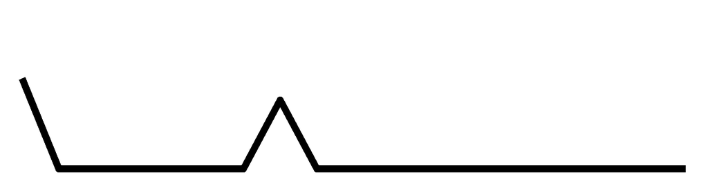

Sydney Johnson

NA

NA

NA

NA

NA

NA

NA

6

NA

NA

NA

NA

NA

NA

NA

NA

NA

NA

NA

0.00

1

0.4286

0.0226

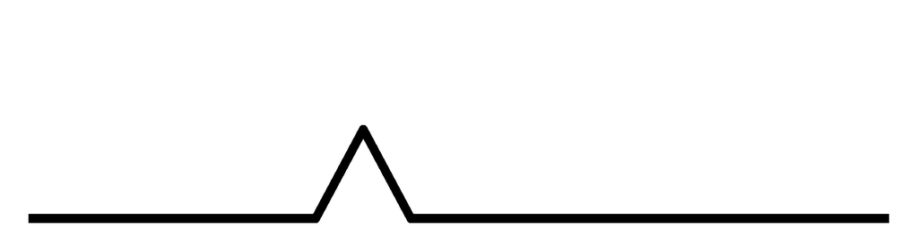

Congrats Caroline Swenson for having the best cadet picks this week, with a correct percentage of 0.75, Congrats Sydney Shannon for having the best cadet picks this week, with a correct percentage of 0.75, Congrats Gabriela Peralta for having the best cadet picks this week, with a correct percentage of 0.75

| Name | Week 1 | Week 2 | Week 3 | Week 4 | Week 5 | Week 6 | Week 7 | Week 8 | Week 9 | Week 10 | Week 11 | Week 12 | Week 13 | Week 14 | Week 15 | Week 16 | Week 17 | Week 18 | Week 19 | Percent | Weeks Picked | Season Percent | Adj Season Percent | Season Trend |
| --- | --- | --- | --- | --- | --- | --- | --- | --- | --- | --- | --- | --- | --- | --- | --- | --- | --- | --- | --- | --- | --- | --- | --- | --- |
| Caroline Swenson | 8 | 12 | 11 | 13 | 7 | 8 | 10 | NA | 8 | 9 | 8 | NA | 12 | 11 | 12 | 8 | 13 | 4 | 3 | 0.75 | 17 | 0.6767 | 0.6055 |  |
| Sydney Shannon | 10 | 9 | 8 | 9 | 8 | 7 | 9 | 5 | 8 | 10 | 8 | 10 | 11 | 10 | 11 | 12 | 12 | 4 | 3 | 0.75 | 19 | 0.626 | 0.626 |  |
| Gabriela Peralta | 11 | 8 | 9 | NA | 8 | 8 | 10 | 6 | NA | 8 | 6 | 10 | 12 | NA | 12 | NA | NA | 4 | 3 | 0.75 | 14 | 0.615 | 0.4532 |  |
| John White | 10 | 11 | 10 | 8 | 12 | 9 | 11 | 6 | 9 | 9 | 8 | 10 | 8 | 11 | 10 | 10 | 12 | 6 | 2 | 0.50 | 19 | 0.6565 | 0.6565 |  |
| Thomas Bizub | 10 | 14 | 8 | 11 | 8 | 9 | 10 | 8 | 10 | 12 | 9 | 11 | 9 | 10 | NA | NA | NA | NA | NA | 0.00 | 14 | 0.678 | 0.4996 |  |
| Amadou Bah | 9 | NA | NA | NA | NA | NA | NA | NA | NA | NA | NA | NA | NA | NA | NA | 12 | NA | NA | NA | 0.00 | 2 | 0.6774 | 0.0713 |  |
| Kieran Place | 12 | 11 | 8 | NA | 10 | 10 | 9 | NA | NA | NA | NA | NA | NA | NA | NA | NA | NA | NA | NA | 0.00 | 6 | 0.6742 | 0.2129 |  |
| Luca Testa | NA | NA | 10 | NA | NA | NA | NA | NA | NA | NA | NA | NA | NA | NA | NA | NA | NA | NA | NA | 0.00 | 1 | 0.6667 | 0.0351 |  |
| Laurence Dowd | 10 | 10 | 10 | 9 | 10 | NA | 12 | NA | 10 | 8 | 7 | NA | 10 | NA | NA | NA | NA | NA | NA | 0.00 | 10 | 0.6575 | 0.3461 |  |
| Joshua Loyd | 11 | 9 | 8 | NA | 6 | 9 | NA | 6 | 10 | 8 | NA | 10 | 9 | 11 | 12 | 12 | 13 | 3 | NA | 0.00 | 15 | 0.6343 | 0.5008 |  |
| Jonathan Kemp | 10 | 10 | NA | NA | 11 | 10 | 11 | 7 | 8 | 6 | 8 | 12 | 8 | 9 | NA | NA | NA | NA | NA | 0.00 | 12 | 0.6286 | 0.397 |  |
| Paige Lennon | NA | NA | NA | 11 | 10 | 8 | 11 | 8 | 6 | 8 | 6 | 9 | 11 | 10 | 11 | NA | NA | NA | NA | 0.00 | 12 | 0.6264 | 0.3956 |  |
| Zakai Bufkin | 8 | 11 | 7 | 9 | 8 | 10 | 9 | 7 | 9 | 9 | NA | 10 | NA | NA | NA | 12 | NA | NA | NA | 0.00 | 12 | 0.6158 | 0.3889 |  |
| Christopher Erb | 9 | 9 | 7 | 11 | 9 | 11 | 8 | 11 | 10 | 9 | 5 | 10 | 9 | 8 | NA | NA | NA | NA | NA | 0.00 | 14 | 0.6146 | 0.4529 |  |
| Victor Olawale-Apanpa | 8 | NA | 10 | NA | 10 | NA | 10 | 7 | 7 | 9 | 6 | 11 | 10 | NA | NA | NA | NA | NA | NA | 0.00 | 10 | 0.6069 | 0.3194 |  |
| Sidney Cash | 10 | 10 | NA | 10 | NA | 8 | 8 | 7 | 11 | 8 | 5 | 10 | 10 | 8 | NA | NA | NA | NA | NA | 0.00 | 12 | 0.5966 | 0.3768 |  |
| Cameron Patterson | 11 | 9 | 8 | NA | NA | NA | NA | NA | NA | NA | NA | NA | NA | NA | NA | NA | NA | NA | NA | 0.00 | 3 | 0.5957 | 0.0941 |  |
| Joshua Gilliard | 9 | 8 | 9 | 10 | 10 | 7 | 10 | 7 | 5 | 8 | NA | 10 | 10 | NA | NA | NA | NA | NA | NA | 0.00 | 12 | 0.5819 | 0.3675 |  |
| Margaret Williams | 9 | NA | NA | NA | NA | NA | NA | NA | NA | NA | NA | NA | NA | NA | NA | NA | NA | NA | NA | 0.00 | 1 | 0.5625 | 0.0296 |  |
| Logan Kauina | 9 | NA | NA | NA | NA | NA | NA | NA | NA | NA | NA | NA | NA | NA | NA | NA | NA | NA | NA | 0.00 | 1 | 0.5625 | 0.0296 |  |
| Caleb John | NA | 9 | NA | NA | NA | NA | NA | NA | NA | NA | NA | NA | NA | NA | NA | NA | NA | NA | NA | 0.00 | 1 | 0.5625 | 0.0296 |  |
| Jay Hajost | 11 | 7 | 10 | NA | 6 | NA | NA | 7 | 9 | NA | NA | NA | NA | NA | NA | NA | NA | NA | NA | 0.00 | 6 | 0.5618 | 0.1774 |  |
| Ryan Jackovic | 11 | 10 | NA | 7 | 7 | 8 | 8 | 7 | NA | 4 | 5 | NA | 12 | 10 | NA | NA | NA | NA | NA | 0.00 | 11 | 0.5562 | 0.322 |  |
| August Rannow | 9 | NA | NA | NA | 7 | NA | NA | NA | NA | NA | NA | NA | NA | NA | NA | NA | NA | NA | NA | 0.00 | 2 | 0.5333 | 0.0561 |  |
| Peter Digenan | 9 | 6 | 8 | 10 | 7 | NA | NA | NA | NA | NA | NA | NA | NA | NA | NA | NA | NA | NA | NA | 0.00 | 5 | 0.5263 | 0.1385 |  |
| Caleb Doyle | 9 | NA | NA | NA | NA | NA | NA | 6 | NA | NA | NA | NA | NA | NA | NA | NA | NA | NA | NA | 0.00 | 2 | 0.5 | 0.0526 |  |
| Sydney Johnson | NA | NA | NA | NA | NA | NA | NA | 6 | NA | NA | NA | NA | NA | NA | NA | NA | NA | NA | NA | 0.00 | 1 | 0.4286 | 0.0226 |  |

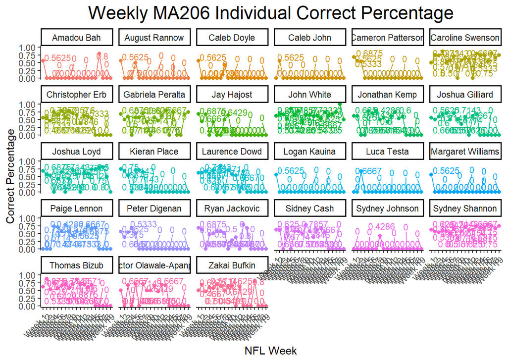

## Combined cadet and instructor prediction

This Week's Combined Cadet and Instructor Predictions

Week 19

| Game | Prediction | Winner | Correct | Correct Votes | Correct Percent |
| --- | --- | --- | --- | --- | --- |
| 1 | Green Bay Packers | Green Bay Packers | Yes | 18 | 0.9474 |
| 2 | Buffalo Bills | Buffalo Bills | Yes | 12 | 0.6316 |
| 3 | Kansas City Chiefs | Kansas City Chiefs | Yes | 17 | 0.8947 |
| 4 | New Orleans Saints | Tampa Bay Buccaneers | No | 7 | 0.3684 |

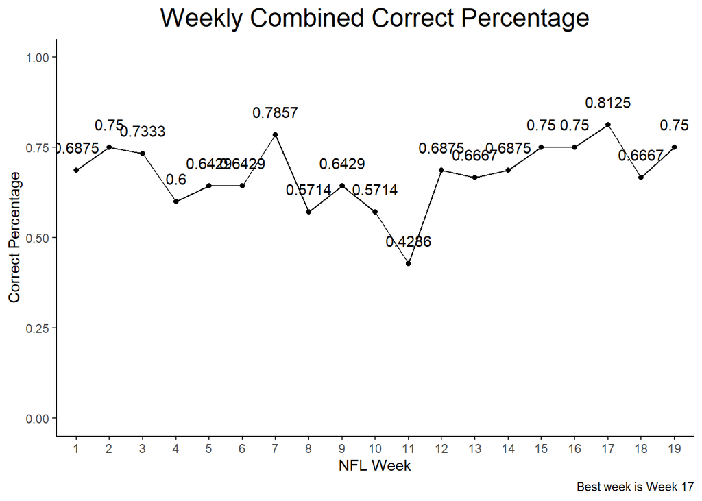

Our combined win percentage for the week is 0.75

Our season combined win percentage so far is 0.6832

19 total predictions this week

This Week's Matched Cadet and Instructor Predictions

Week 19

| Game | Prediction | Correct |
| --- | --- | --- |
| 1 | Green Bay Packers | Yes |
| 2 | Buffalo Bills | Yes |
| 3 | Kansas City Chiefs | Yes |
| 4 | New Orleans Saints | No |

[figure not shown]

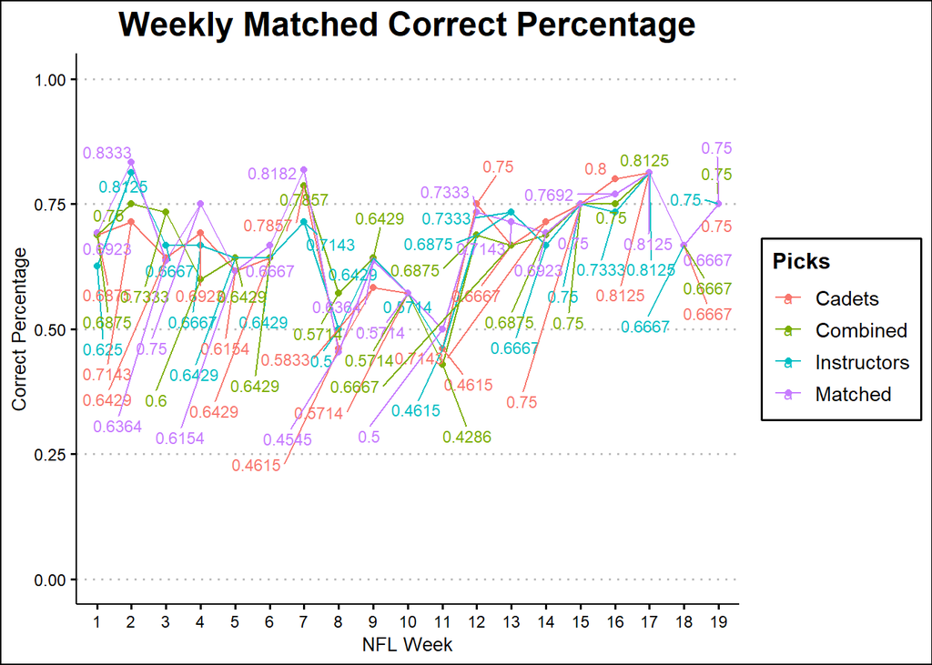